# Checkpoint 2 - Problema 2

26 de julho de 2016

```r
library(dplyr, warn.conflicts = FALSE)
library(ggplot2)
library(knitr)
theme_set(theme_bw())
```

```r
ler_gastos <- function(arquivo = "dados/ano-atual.csv"){

  require("dplyr", warn.conflicts = FALSE)

  gastos = read.csv(arquivo, stringsAsFactors = FALSE, encoding='UTF-8')
  gastos = gastos %>%
    mutate_each(funs(as.factor), sgPartido, sgUF, txNomeParlamentar, indTipoDocumento)
  return(gastos)
}

gastos <- ler_gastos()


gastos <- gastos %>% select (1,2, 5, 6, 15, 23)

names(gastos) <- c("Partido", "Mes", "Nome", "UF", "Tipo", "Valor")

gastos_pb <- gastos %>% filter (UF == "PB")
gastos_pb <- gastos_pb %>% filter (Mes != 7)
```

## Gastos dos deputados paraibanos em 2016

A ideia geral é observar o total gasto por cada deputado paraibano no período compreendido entre janeiro e junho de 2016.

Cada barra representa o valor total gasto no período observado e as cores representam os partidos. Além disso, também são mostradas bolinhas preenchidas pretas para indicar cada subgasto do deputado, que juntos nos levam ao valor total mostrado. O objetivo foi identificar algum ponto estranho em todos esses subgastos dos deputados. O deputado que mais gastou, Rômulo Gouveia, por exemplo, apresenta subgastos bem pequenos, já que todos os seus pontos estão concentrados em valores muito baixos. Já Benjamim Maranhão tem um ponto que se destaca dos demais, apenas aquele seu subgasto praticamente superou o total de Pedro Cunha Lima.

Alguns subgastos também apresentam valores negativos. Isso acontece para situações de emissão de bilhetes aéreos, significando que o referido bilhete é um bilhete de compensação, pois compensa um outro bilhete emitido e não utilizado pelo deputado.

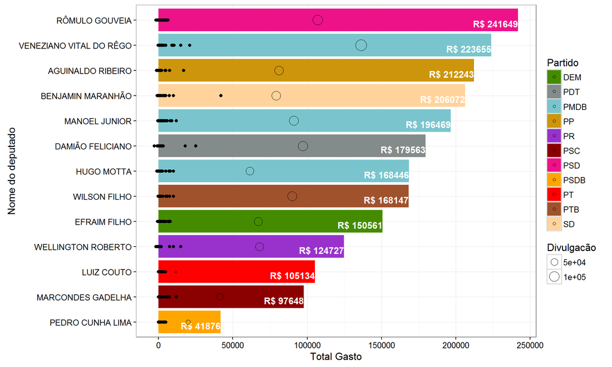

```r
agrupa_atividade = gastos_pb %>% filter(Tipo == "DIVULGAÇÃO DA ATIVIDADE PARLAMENTAR.") %>% group_by(Nome, Partido) %>% summarise(Divulgacão = sum(Valor))


agrupa_nome = gastos_pb %>%
  group_by(Nome, Partido) %>%
  summarise(total_gasto = sum(Valor))

ggplot(agrupa_nome, aes(x = reorder(Nome, total_gasto),
                        y = total_gasto,
                        fill = Partido)) +
  geom_bar(stat = "summary", fun.y = "mean") +

  scale_fill_manual(values = c("chartreuse4", "azure4", "cadetblue3", "darkgoldenrod3", "darkorchid", "darkred", "deeppink2", "orange", "red", "Sienna", "burlywood1")) +

  geom_text(aes(label = sprintf("R$ %i",as.integer(total_gasto))), hjust=1, vjust=1, fontface = "bold", colour = "white") +
  xlab("Nome do deputado") +
  ylab("Total Gasto") + coord_flip() +
    geom_point(data = gastos_pb, aes(x = Nome, y = Valor), colour = "black", show.legend = FALSE) +
  geom_point(data = agrupa_atividade, aes(x = Nome, y = Divulgacão, size = Divulgacão), colour = "black", show.legend = TRUE, shape = 21)
```

Entretanto, ainda temos um ponto estranho no gráfico anterior, que foi o pequeno valor gasto por Pedro Cunha Lima. Na verdade, Pedro tirou licença no fim do ano passado e assumiu Marcondes Gadelha, seu suplente. O fato dos dois serem os que menos gastaram pode ser explicado por tal fato. A fim de garantir uma comparação mais justa, os gastos totais e com divulgação da atividade parlamentar dos dois deputados foram agrupados em um só. Nessa perspectiva, o deputado que menos gasta passa a ser Luiz Couto.

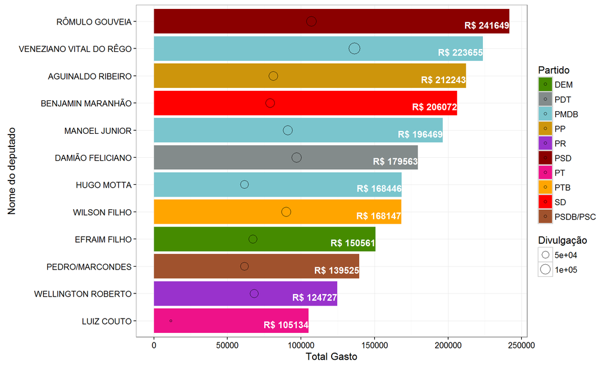

```r
agrupa_atividade = gastos_pb %>% filter(Tipo == "DIVULGAÇÃO DA ATIVIDADE PARLAMENTAR.") %>% group_by(Nome, Partido) %>% summarise(Divulgação = sum(Valor))

newLine <- data.frame(Nome = "PEDRO/MARCONDES", Partido="PSDB/PSC", Divulgação=61580)
agrupa_atividade <- agrupa_atividade %>% filter (Nome != "PEDRO CUNHA LIMA" & Nome != "MARCONDES GADELHA")
agrupa_atividade <- rbind.data.frame(agrupa_atividade, newLine)

newRow <- data.frame(Nome = "PEDRO/MARCONDES",Partido="PSDB/PSC",total_gasto=139525.49)
agrupa_nome <- rbind.data.frame(agrupa_nome,newRow)
agrupa_nome <- agrupa_nome %>% filter (Nome != "PEDRO CUNHA LIMA" & Nome != "MARCONDES GADELHA")

ggplot(agrupa_nome, aes(x = reorder(Nome, total_gasto),
                        y = total_gasto,
                        fill = Partido)) +
  geom_bar(stat = "summary", fun.y = "mean") +

  scale_fill_manual(values = c("chartreuse4", "azure4", "cadetblue3", "darkgoldenrod3", "darkorchid", "darkred", "deeppink2", "orange", "red", "Sienna", "burlywood1")) +

  geom_text(aes(label = sprintf("R$ %i",as.integer(total_gasto))), hjust=1, vjust=1, fontface = "bold", colour = "white") +
  xlab("Nome do deputado") +
  ylab("Total Gasto") + coord_flip() +
  geom_point(data = agrupa_atividade, aes(x = Nome, y = Divulgação, size = Divulgação), colour = "black", show.legend = TRUE, shape = 21)
```